Tyler Grimes  
Feb. 2, 2016  
Homework 4

### Ch. 4 #3, 14a, and 15; Ch. 5 #10.

##### 3.) Give an efficient algorithm to simulate the value of a random variable $X$ such that

$$P(X=1)=0.3, P(X=2)=0.2, P(X=3)=0.35, P(X=4)=0.15$$

##### Derivation

We will use a slight variation of the discrete inverse transform method to generate $X$. Rather than use the cdf, we will organize the values of $X$ from most probable to least. The probabilities are accumulated in this order, creating the function
$$F(x) =
\begin{cases}
0.35 & , x = 3 \\
0.65 & , x = 1 \\
0.85 & , x = 2 \\
1 & , x = 4 \\
\end{cases}.$$

The notation $F(x)$ is used for this function, but note it is not a cdf. However, by ordering from largest probabilities to smallest, we will need to perform less comparisons (on average) when running the algorithm.

##### Algorithm

To generate a variable from the distribution,

1. Generate $u \sim Unif(0, 1)$.
2. If $u < 0.35$ set $X=3$  
   Else if $u < 0.65$ set $X=1$  
   Else if $u < 0.85$ set $X=2$  
   Else set $X=4$

##### Simulation

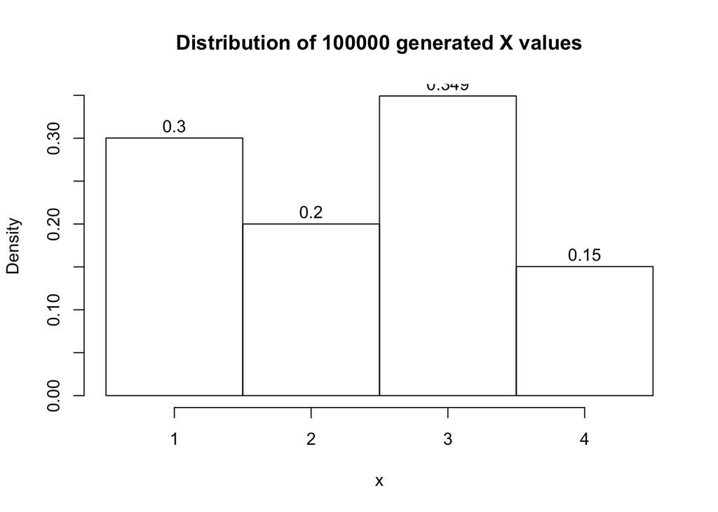

```r
set.seed(12)
rX <- function() {
  u <- runif(1, 0, 1)
  if(u < 0.35) return(3)
  if(u < 0.65) return(1)
  if(u < 0.85) return(2)
  return(4)
}

x <- numeric(100000)
for(i in 1:100000) { x[i] <- rX() }
hist(x, breaks = c(0.5, 1.5, 2.5, 3.5, 4.5), labels = T, freq = F,
     main = "Distribution of 100000 generated X values")
```

##### 14.) Let X be a binomial random variable with parameters $n$ and $p$. Suppose that we want to generate a random variable $Y$ whose probability mass function is the same as the conditional mass function of $X$ given that $X \geq k$, for some $k \leq n$. Let $\alpha = P(X \geq k)$ and suppose that the value of $\alpha$ has been computed.

##### (a) Give the inverse transform method for generating $Y$.

##### Derivation

Let $Y_k$ denote the random variable with the pmf
$$P(Y_k = y) = \frac{P(X = y {|} y \geq k)}{P(X \geq k)} =
\begin{cases}
\frac{1}{\alpha}{n \choose y}p^y(1-p)^{n-y} & , y = k, k+1, ... n \\
0 & , \text{otherwise}
\end{cases}.$$

The cdf of $Y_k$ is
$$P(Y_k \leq y) = \frac{1}{\alpha} \sum_{x=k}^{y} {n \choose x}p^x(1-p)^{n-x} = F_k(y)$$

##### Algorithm

We assume $p$, $n$, $k$, and $\alpha$ are provided. To generate a variable from the distribution,

1. Generate $u \sim Unif(0, 1)$.
2. For y from k to n  
   If $F_k(y - 1) < y < F_k(y)$, set Y = y.

##### Simulation

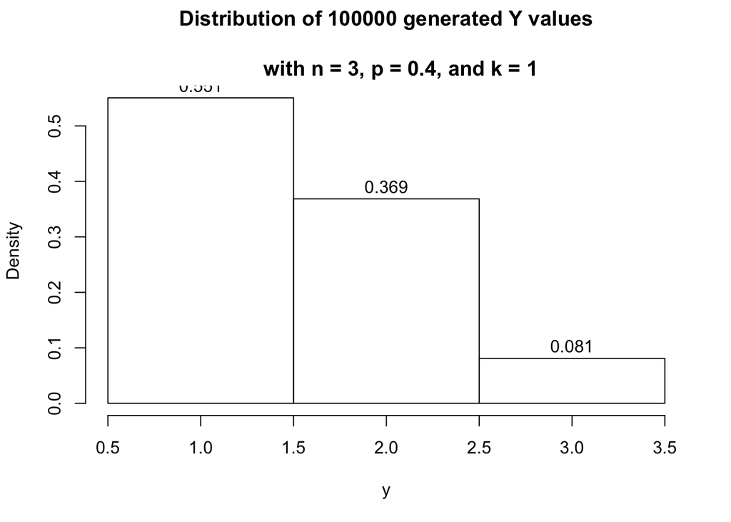

```r
#Cdf of Y.
FY <- function(y, n, p, k) {
  alpha <- 1 - pbinom((k-1), n, p)
  #sum(dbinom(seq(k, y, 1), n, p))/alpha
  (pbinom(y, n, p) - pbinom((k-1), n, p))/alpha
}

#Generate random y.
rY <- function(n, p, k) {
  u <- runif(1, 0, 1)
  upperBounds <- numeric(n - k + 1)
  for(j in k:n) {
    upperBounds[j - k + 1] <- FY(j, n, p, k)
  }
  y <- k + sum(u > upperBounds)
  y
}

n = 3
p = 0.4
k = 1
y <- numeric(100000)
for(i in 1:100000) {
  y[i] <- rY(n, p, k)
}
hist(y, seq(k - 0.5, n + 0.5, 1), labels = T, freq = F,
     main = "Distribution of 100000 generated Y values\n
     with n = 3, p = 0.4, and k = 1")
```

##### Analytical

In the simulation we used $n = 3$, $p = 0.4$, and $k = 1$. For this distribution, $\alpha = P(Y \geq 1) = 1 - P(Y \leq 0) = 1 - (1-0.4)^3 = 0.784$. The distribution of $Y_k$ is
$$P(Y = y) =
\begin{cases}
\frac{1}{0.784}{3 \choose 1}(0.4)^1(1-0.4)^{3-1} \approx 0.55102 & , y = 1 \\
\frac{1}{0.784}{3 \choose 2}(0.4)^2(1-0.4)^{3-2} \approx 0.36735 & , y = 2 \\
\frac{1}{0.784}{3 \choose 3}(0.4)^3(1-0.4)^{3-3} \approx 0.08163 & , y = 3 \\
0 & , \text{otherwise}
\end{cases}.$$

The distribution of the simulated sample agrees with the expected distribution to two decimal places.

##### 15.) Give a method for simulating $X$, having the probability mass function $p_j$, $j=5,6,...,14$, where

$$P_j =
\begin{cases}
0.11 & \text{when $j$ is odd and $5 \leq j \leq 13$} \\
0.09 & \text{when $j$ is even and $6 \leq j \leq 14$}
\end{cases}$$

Use the text’s random number sequence to generate $X$

##### Derivation

Using the composition method, we can break up the pmf into two pieces
$$p_j = \frac{11}{20}p_{1j} + \frac{9}{20}p_{2j},$$
where $p_{1j}=1/5$ for $j=5, 7, ... 13$, $0$ elsewhere, and $p_{2j}=1/5$ for $j=6, 8, ... 14$, $0$ elsewhere. We can easily verify that these are valid pmfs; they are nonnegative, and both sum to 1 over their support.

##### Algorithm

To generate a variable from the distribution,

1. Generate $u_1, u_2 \sim Unif(0, 1)$
2. If $u_1 < \frac{11}{20}$, $x = 2\lceil{5u_2}\rceil+3$  
   Else $x = 2\lceil{5u_2}\rceil+4$

##### Simulation

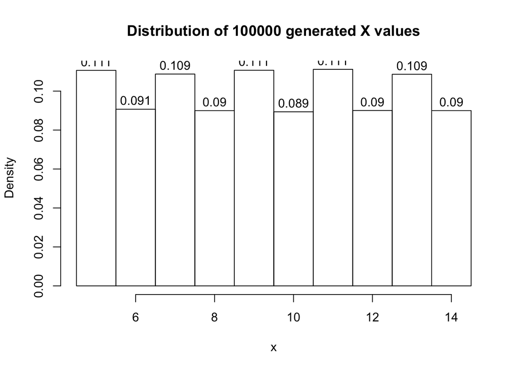

```r
rX <- function(n = 1) {
  u1 <- runif(n, 0, 1)
  u2 <- runif(n, 0, 1)
  x <- numeric(n)
  cond1 <- u1 < 11/20
  x[cond1] <- 2*ceiling(5*u2[cond1]) + 3
  x[!cond1] <- 2*ceiling(5*u2[!cond1]) + 4
  x
}

x <- rX(100000)
hist(x, breaks = c(seq(4.5, 14.5, 1)), labels = T, freq = F,
     main = "Distribution of 100000 generated X values")
```

##### 10.) A casualty insurance company has $1000$ policyholders, each of whom will independently present a claim in the next month with probability $0.05$. Assuming that the amounts of the claims made are independent exponential random variables with mean $\$800$, use simulation to estimate the probability that the sum of these claims exceeds $\$50,000$.

##### Derivation

To generate an obsevation from this population of claims, we need to first generate a number $k$ from a Binomial($1000, 0.05$) distribution. This will be the number of claims made in the month. Then, we generate $k$ numbers, $x_1,...,x_k$ from an Exponential($\lambda = \frac{1}{800}$) and take their sum, $S$.

##### Algorithm

Assuming we have a way to generate random numbers from an exponential and binomial, to generate a random $S$,

1. Generate a random $k \sim Bin(1000, 0.05$.
2. Generate $x_1, ...,x_k \sim \text{iid } Exp(1/800)$.
3. Evaluate $S = \sum x_i$.

##### Simulation

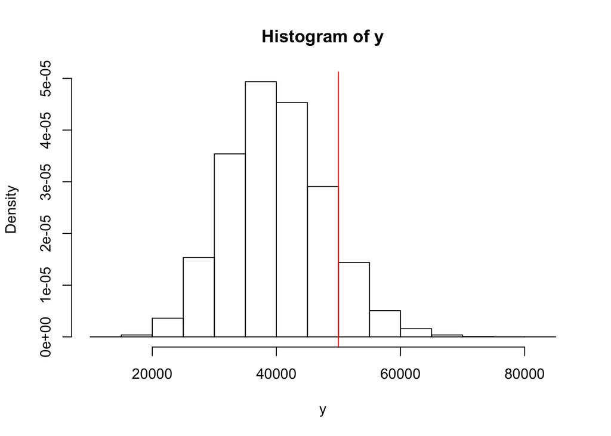

```r
rep <- 100000
p <- 0.05
n <- 1000
mean <- 800
y <- numeric(rep)
for(i in 1:rep) {
  k <- rbinom(1, n, p)
  if(k == 0) {
    y[i] = 0
  }
  else {
    y[i] <- sum(rexp(k, 1/800))
  }
}

hist(y, freq = F)
abline(v = 50000, col = "red", main = "Distirbution of 100000 monthly total claims")
```

```r
mean(y > 50000)
```

```
## [1] 0.1075
```

##### Analytical

Let $K \sim binom(n, p)$, $x_i \sim \text{iid } exp(\lambda)$, and $S_k = \sum_1^k x_i$. But then, since $S_k$ is a sum of independent exponential random variables, its distribution is Gamma($\alpha = k, \lambda$). Now consider the joint pdf of $S_k$ and $K$,
$$\begin{aligned}
P(S_k = s, K = k) &= P(S_k = s | K = k)P(K = k) \\
&= \frac{1}{\lambda^k\Gamma(k)}s^{k-1}e^\frac{-s}{\lambda}{n \choose k}(p)^k(1-p)^{n-k}, \text{for k = 0, 1, ..., n.}
\end{aligned}$$

Since our main interest is on $P(S_k > s)$, we need the marginal distirbution of $S_k$. Since $k$ is an integer, we can obtain the conditional cdf of $S_k$ by using integration by parts $k$ times:
$$\begin{aligned}
P(S_k \leq s,| K = k) &= \int_0^s \frac{1}{\lambda^k\Gamma(k)}x^{k-1}e^\frac{-x}{\lambda} dx \\
&= 1 - \sum_{n=0}^{k-1} \frac{e^{\frac{-s}{\lambda}}}{n!} \left( \frac{s}{\lambda}\right)^n
\end{aligned}.$$

Now to obtain $P(S_k > s)$, we sum the joint distribution over the support of $K$
$$\begin{aligned}
P(S_k > s) &= \sum_{k=0}^{n} P(S_k > s, K = k) \\
&= \sum_{k=0}^{n} \sum_{m=0}^{k-1} \left[ \frac{e^{\frac{-s}{\lambda}}}{m!} \left( \frac{s}{\lambda}\right)^m \right] {n \choose k}(p)^k(1-p)^{n-k}
\end{aligned}$$

Without any obvious ways to simplify this expression, we will leave the expression here. If we were to perform this calculation using $n=1000$ we would need to compute $1000!$. So instead, we will use an approximation and only sum from $n=0$ to $90$. While this is only a portion of the entire support of $k$, the probability that it is outside of this range is less than $10^-7$.

$$P(S_k > 50000) \approx \sum_{k=0}^{90} \sum_{m=0}^{k-1} \left[ \frac{e^{\frac{-50000}{800}}}{m!} \left( \frac{50000}{800}\right)^m \right] {1000 \choose k}(0.05)^k(1-0.05)^{1000-k}$$

```r
s <- 50000
n <- 1000
p <- 0.05
lambda <- 800
pSk <- function(s, n, p, lambda) {
  approx <- 90
  terms <- numeric(approx)
  for(i in 1:approx) {
    terms[i] <- sum(exp(-s/lambda)/factorial(0:(i-1))*(s/lambda)^(0:(i-1)))*dbinom(i, n, p)
  }
  sum(terms)
}

pSk(s, n, p, lambda)
```

```
## [1] 0.1070977
```